## Name: Manideep Reddy Mandhadi

# Project name: Olympic Games

## Objective of the research

The file athlete_events.csv contains 271116 rows and 15 columns. Each row corresponds to an individual athlete competing in an individual Olympic event (athlete-events). The columns are:

ID - Unique number for each athlete  
Name - Athlete's name  
Sex - M or F  
Age - Integer  
Height - In centimeters  
Weight - In kilograms  
Team - Team name  
NOC - National Olympic Committee 3-letter code  
Games - Year and season  
Year - Integer  
Season - Summer or Winter  
City - Host city  
Sport - Sport  
Event - Event  
Medal - Gold, Silver, Bronze, or NA

```r
library(tidyverse)
```

### Loading the data

```r
data = read.csv('athlete_events.csv', na.strings="",stringsAsFactors=FALSE)
```

```r
nrow(data)
```

271116

```r
cat("Display top 10 rows:") # print message
head (data,n=10) # print top 10 rows
cat("\n \n")
cat ("Number of Rows: ",nrow(data)) # calculate number of rows
cat ("\nNumber of Columns: ",ncol(data)) # calculate number of coloumns
```

```
Display top 10 rows:
```

A data.frame: 10 × 15

|  | ID <int> | Name <chr> | Sex <chr> | Age <chr> | Height <chr> | Weight <chr> | Team <chr> | NOC <chr> | Games <chr> | Year <int> | Season <chr> | City <chr> | Sport <chr> | Event <chr> | Medal <chr> |
| --- | --- | --- | --- | --- | --- | --- | --- | --- | --- | --- | --- | --- | --- | --- | --- |
| 1 | 1 | A Dijiang | M | 24 | 180 | 80 | China | CHN | 1992 Summer | 1992 | Summer | Barcelona | Basketball | Basketball Men's Basketball | NA |
| 2 | 2 | A Lamusi | M | 23 | 170 | 60 | China | CHN | 2012 Summer | 2012 | Summer | London | Judo | Judo Men's Extra-Lightweight | NA |
| 3 | 3 | Gunnar Nielsen Aaby | M | 24 | NA | NA | Denmark | DEN | 1920 Summer | 1920 | Summer | Antwerpen | Football | Football Men's Football | NA |
| 4 | 4 | Edgar Lindenau Aabye | M | 34 | NA | NA | Denmark/Sweden | DEN | 1900 Summer | 1900 | Summer | Paris | Tug-Of-War | Tug-Of-War Men's Tug-Of-War | Gold |
| 5 | 5 | Christine Jacoba Aaftink | F | 21 | 185 | 82 | Netherlands | NED | 1988 Winter | 1988 | Winter | Calgary | Speed Skating | Speed Skating Women's 500 metres | NA |
| 6 | 5 | Christine Jacoba Aaftink | F | 21 | 185 | 82 | Netherlands | NED | 1988 Winter | 1988 | Winter | Calgary | Speed Skating | Speed Skating Women's 1,000 metres | NA |
| 7 | 5 | Christine Jacoba Aaftink | F | 25 | 185 | 82 | Netherlands | NED | 1992 Winter | 1992 | Winter | Albertville | Speed Skating | Speed Skating Women's 500 metres | NA |
| 8 | 5 | Christine Jacoba Aaftink | F | 25 | 185 | 82 | Netherlands | NED | 1992 Winter | 1992 | Winter | Albertville | Speed Skating | Speed Skating Women's 1,000 metres | NA |
| 9 | 5 | Christine Jacoba Aaftink | F | 27 | 185 | 82 | Netherlands | NED | 1994 Winter | 1994 | Winter | Lillehammer | Speed Skating | Speed Skating Women's 500 metres | NA |
| 10 | 5 | Christine Jacoba Aaftink | F | 27 | 185 | 82 | Netherlands | NED | 1994 Winter | 1994 | Winter | Lillehammer | Speed Skating | Speed Skating Women's 1,000 metres | NA |

```
Number of Rows:  271116
Number of Columns:  15
```

### One column selection

#### select a column from dataset

#### select column "Height" and store it variable name Height

#### missing values are replaced by zero

#### factor to interger conversion

#### print 10 largest values of height

```r
# select a column from dataset
Height <- data$Height # select column "Weight" and store it variable name Weight
Height[Height=="NA"] <- "0" # missing values are replaced by zero
Height<-as.numeric(Height) # factor to interger conversion
cat("10 largest values [Height]:",head(sort(Height,decreasing=TRUE),10)) # print 10 largest values
```

```
10 largest values [Height]: 226 226 226 223 223 223 223 221 221 221
```

```r
# create new dataset: 5 columns
dataset<-data[data$Medal=="Bronze",c("Age", "Team","City","Sport","Medal")] # dataset based on gold medal
#Ozone <- na.omit(data$Ozone)
#dataset<-na.omit(data$dataset)
cat("Data based on Bronze medal: ")
head(dataset,5) # print top 5 rows of new dataset
```

```
Data based on Bronze medal:
```

A data.frame: 5 × 5

|  | Age <chr> | Team <chr> | City <chr> | Sport <chr> | Medal <chr> |
| --- | --- | --- | --- | --- | --- |
| 38 | 30 | Finland | Antwerpen | Swimming | Bronze |
| 39 | 30 | Finland | Antwerpen | Swimming | Bronze |
| 41 | 28 | Finland | Sochi | Ice Hockey | Bronze |
| 42 | 28 | Finland | London | Gymnastics | Bronze |
| 51 | 32 | Finland | Helsinki | Gymnastics | Bronze |

```r
# Load athletes_events data
olympic <- read_csv("athlete_events.csv",
                 col_types = cols(
                   ID = col_character(),
                   Name = col_character(),
                   Sex = col_factor(levels = c("M","F")),
                   Age =  col_integer(),
                   Height = col_double(),
                   Weight = col_double(),
                   Team = col_character(),
                   NOC = col_character(),
                   Games = col_character(),
                   Year = col_integer(),
                   Season = col_factor(levels = c("Summer","Winter")),
                   City = col_character(),
                   Sport = col_character(),
                   Event = col_character(),
                   Medal = col_factor(levels = c("Gold","Silver","Bronze"))
                 )
)
```

## Data Exploration

### four different aspects

```r
medalist <- olympic %>%
  filter(!is.na(Medal))


medalist %>%
  group_by(Medal) %>%
  summarise(
    mean = mean(Age, na.rm = TRUE)
  )
```

A tibble: 3 × 2

| Medal <fct> | mean <dbl> |
| --- | --- |
| Gold | 25.90101 |
| Silver | 25.99672 |
| Bronze | 25.87921 |

#### Let’s check the average age of the medalists chronologically. First, the Summer Olympic Games.

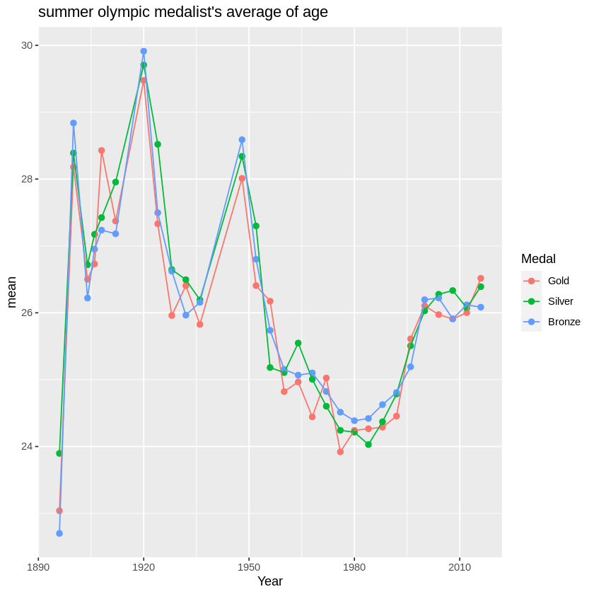

```r
summer_medalist <-
medalist %>%
  group_by(Year, Season, Medal) %>%
  filter(Season == "Summer") %>%
  summarise(
    mean = mean(Age, na.rm = TRUE)
  )


ggplot(data = summer_medalist,
       mapping = aes(x = Year, y= mean, group = Medal, color = Medal)) +
  geom_point(size=2) +
  geom_line() +
  ggtitle("summer olympic medalist's average of age")
```

```
Warning message:
“Removed 1 rows containing missing values (geom_point).”
```

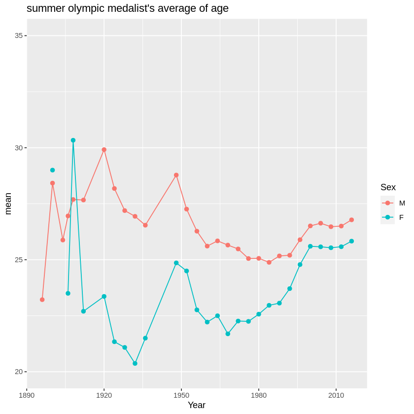

```r
summer_medalist_sex <-
  medalist %>%
  filter(Season == "Summer") %>%
  group_by(Year, Sex) %>%
    summarise(
    mean = mean(Age, na.rm = TRUE)
  )

ggplot(data = summer_medalist_sex,
       mapping = aes(x = Year, y= mean, group = Sex, color = Sex)) +
  geom_point(size=2) +
  geom_line() +
  ggtitle("summer olympic medalist's average of age") +
  ylim(20,35)
```

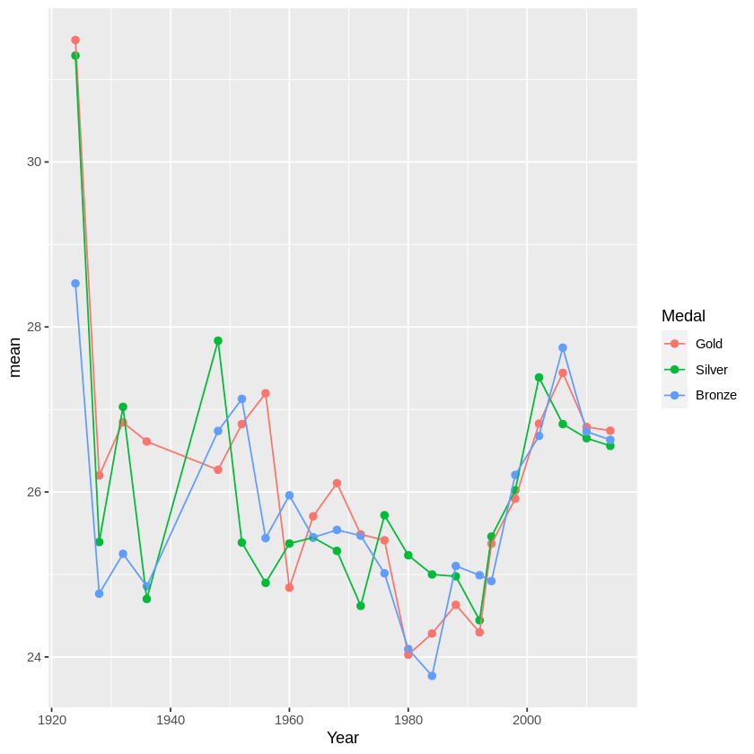

```r
medalist_winter <-
  medalist %>%
  group_by(Year, Season, Medal) %>%
  filter(Season == "Winter") %>%
  summarise(
    mean = mean(Age, na.rm = TRUE)
  )

ggplot(data = medalist_winter, mapping = aes(x= Year, y= mean, group = Medal, color = Medal)) +
  geom_point(size=2) +
  geom_line()
```

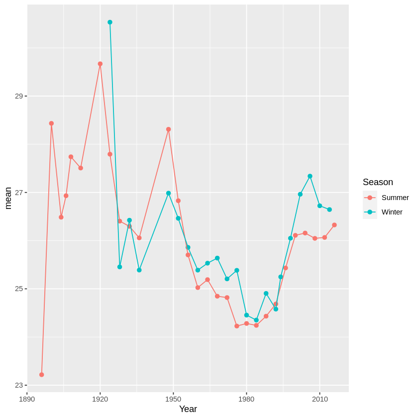

```r
season_medalist <-
medalist %>%
  group_by(Season, Year) %>%
  summarise(
    mean = mean(Age, na.rm = TRUE)
  )


ggplot( data = season_medalist,
  mapping = aes(x= Year, y= mean, group = Season, color = Season)) +
  geom_point(size=2) +
  geom_line()
```

The winter Olympic Games are slightly higher than the summer games. It is on an upward trend since the 1980s.

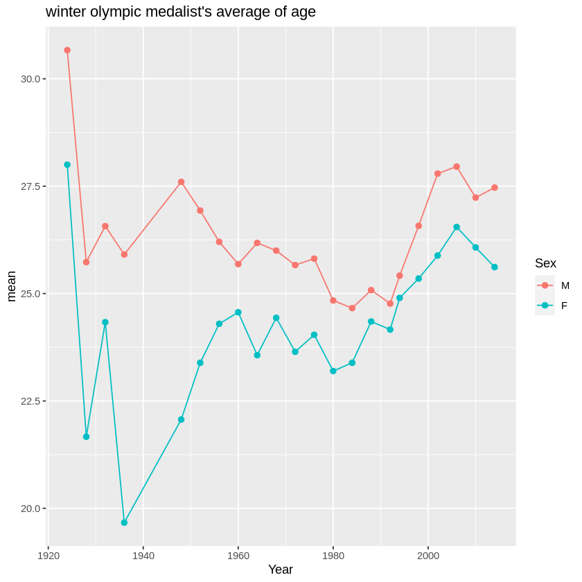

```r
winter_medalist <-
  medalist %>%
  group_by(Year, Season, Sex) %>%
  filter(Season == "Winter") %>%
  summarise(
    mean = mean(Age, na.rm = TRUE)
  )

ggplot(data = winter_medalist,
       mapping = aes(x = Year, y= mean, group = Sex, color = Sex)) +
  geom_point(size=2) +
  geom_line() +
  ggtitle("winter olympic medalist's average of age")
```

## **5 Different columns of my choice**

#### create new dataset: 5 columns

#### dataset based on Bronze medal

```r
# create new dataset: 5 columns
new_dataset<-data [data$Medal=="Bronze",c("Age", "Team","Height","Sport","Medal")] # dataset based on gold medal
cat("Dataset based on Bronze medal: ")
head(new_dataset,5) # print top 5 rows of new dataset
# sorting columns : Age
Age <- new_dataset$Age # select column "Weight" and store it variable name Weight
Age[Age=="NA"] <- "0" # missing values are replaced by zero
Age<-as.numeric(Age) # factor to interger conversion
cat("Sorted column [Age-> top 5 values: year]:",head(sort(Age,decreasing=TRUE),5)) # print 5 largest values

# sorting columns : Height
Height <- new_dataset$Height # select column "Weight" and store it variable name Weight
Height[Height=="NA"] <- "0" # missing values are replaced by zero
Height<-as.numeric(Height) # factor to interger conversion
# comments on result
cat("\nSorted column [Height-> top 5 values in S.I unit: cm]:",head(sort(Height,decreasing=TRUE),5)) # print 5 largest values
cat("\n\nResults Explaination:")
cat("\nThe extracted new dataset will give a summary of original dataset. Here, all the required columns are gathered together for achieving our main research goals.  By analyzing it, we can get the idea regarding participants age, height,
weight, sports, and medals.")
```

```
Dataset based on Bronze medal:
```

A data.frame: 5 × 5

|  | Age <chr> | Team <chr> | Height <chr> | Sport <chr> | Medal <chr> |
| --- | --- | --- | --- | --- | --- |
| 38 | 30 | Finland | NA | Swimming | Bronze |
| 39 | 30 | Finland | NA | Swimming | Bronze |
| 41 | 28 | Finland | 184 | Ice Hockey | Bronze |
| 42 | 28 | Finland | 175 | Gymnastics | Bronze |
| 51 | 32 | Finland | 175 | Gymnastics | Bronze |

```
Sorted column [Age-> top 5 values: year]: 72 71 69 65 64
Sorted column [Height-> top 5 values in S.I unit: cm]: 223 223 220 220 218

Results Explaination:
The extracted new dataset will give a summary of original dataset. Here, all the required columns are gathered together for achieving our main research goals.  By analyzing it, we can get the idea regarding participants age, height,
weight, sports, and medals.
```

```r
# Top medal numbers and Sports
medal_table<-as.data.frame(table(new_dataset$Sport, useNA="ifany")) # create dataframe for new dataset based on Sport
frequency<-as.numeric(tail(sort(medal_table$Freq),5)) # top frequency calculation
cat("List of most Olympic Bronze medals: ")
cat("    \n \tSports Name:",head(names(sort(table(new_dataset$Sport),decreasing=TRUE)), 5))# print top 5 sports that has won highest number of medal
cat("\n\tTotal Number:",sort(frequency,decreasing=TRUE))

# Avg. Age
cat("\nAverage Age [year]:",mean(Age))
# Avg. Height
cat("\nAverage Height [cm]:",mean(Height))
# Avg. Weight
cat("\nA\verage Weight [kg]:",mean(Weight))
```

```
List of most Olympic Bronze medals:
 	Sports Name: Athletics Rowing Swimming Gymnastics Fencing
	Total Number: 1296 990 956 719 566
Average Age [year]: 25.31666
Average Height [cm]: 136.4246
Aerage Weight [kg]: 54.30567
```

```r
data.a <- data[data$Age ==25, , drop = FALSE]
data.b <- data.a[data.a$Height ==136, , drop = FALSE]
data.c <- data.b[data.b$Weight ==54, , drop = FALSE]
data.d <- na.omit(data.c)
data.d$"Name"
```

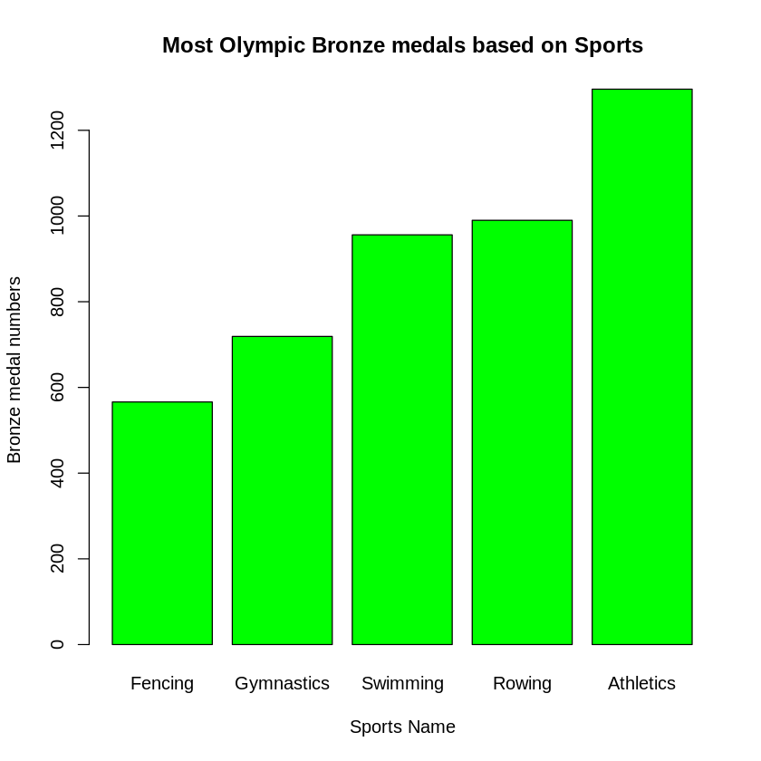

```r
# plot top sports that have won most Bronze medals
sport_name<-tail(names(sort(table(new_dataset$Sport))), 5) # sports name
# plot bar chart
barplot(frequency,names.arg=sport_name,xlab="Sports Name",ylab="Bronze medal numbers",col="green",main="Most Olympic Bronze medals based on Sports")
```

# Description on result

# Summary

The analysis of dataset represents a good insight of Olympic history. The dataset is reliable ( by size, rows: 271116, columns: 15).

In order to select an athlete, we can set categories based on age, height and weight. In my opinion, it will not wise to select participants in according to their achieved medal. Because Olympics holds every 4 yours and athlete performance is mainly age dependents. If we select an athlete based on present performance, he will get older over the years that will slow down his reflex. So, Kellogg's can select athlete based on the winner athletes average age, weight and height.

# Recommendations:¶